# Predicting if whether a constructor work has positive or negative cost

On this project the goal was to predict if a construction work was going to have a negative or positive cost. This was a real world project, using a company's historic data. The data had around 1100 records.

### Importing libraries

```python
import pandas as pd
import numpy as np
import seaborn as sns
import matplotlib.pyplot as plt
import sklearn as skl
```

### Data Quality

This dataset had a lot of errors in terms of the quality of the data. It was necessary to insert the data manually in some cases, and that made it very diverse and unformalized. In this step the goal was to simplify and normalize the data. This required a lot of work and knowledge about the data in question.

Bellow will be a sample of the normalization that was done, not everything, because it would be repetitive and long.

```python
df1 = pd.read_csv(r"C:\Users\user\Desktop\ML\OPCC06_ML.csv",
                  sep = ";",
                  decimal=',',
                  encoding='latin-1',
                  engine='python',
                 )
df1.rename(columns={'OPCC06 - Controlo de Custos e Proveitos de Processos': 'Processo',
                    'Unnamed: 1': 'Obra',
                    'Unnamed: 2': 'Nomecliobra',
                    'Unnamed: 3': 'Directorobra',
                    'Unnamed: 4': 'Tipoobra',
                    'Unnamed: 5': 'Dtabertura',
                    'Unnamed: 6': 'Dtinicio',
                    'Unnamed: 7': 'Dtfecho',
                   'Unnamed: 8': 'Dtconclusao',
                   'Unnamed: 9': 'Prazocontrat',
                   'Unnamed: 10': 'Status',
                   'Unnamed: 11': 'Area',
                    'Unnamed: 12': 'Factor',
                    'Unnamed: 13': 'Custos previstos orc',
                    'Unnamed: 14': 'Custos previstos obra',
                    'Unnamed: 15': 'Custos prev subemp',
                    'Unnamed: 16': 'Facturação prevista orc',
                    'Unnamed: 17': 'Facturação prevista obra',
                    'Unnamed: 18': 'Custos prevmat obra',
                    'Unnamed: 19': 'Custos prevserv obra',
                    'Unnamed: 20': 'Custos materiais',
                    'Unnamed: 21': 'Devolucoes materiais',
                    'Unnamed: 22': 'Custos servicos',
                    'Unnamed: 23': 'Custos diversos',
                    'Unnamed: 24': 'Custos mobrapropria',
                    'Unnamed: 25': 'Custos subemp',
                    'Unnamed: 26': 'Custos autosinterno',
                    'Unnamed: 27': 'Custos equipamentos',
                    'Unnamed: 28': 'Encforn pendentes',
                    'Unnamed: 29': 'Guiasrecepcao pendentes',
                    'Unnamed: 30': 'Facturacao',
                    'Unnamed: 31': 'Autos por facturar',
                    'Unnamed: 32': 'Total custos',
                    'Unnamed: 33': 'Custos fixos',
                    'Unnamed: 34': 'Cobrancas cc',
                    'Unnamed: 35': 'Pendentetotal cc',
                    'Unnamed: 36': 'Pendentetotal cc venc',
                    'Unnamed: 37': 'Autosmed total',
                    'Unnamed: 38': 'Autosmed custos mat',
                    'Unnamed: 39': 'Autosmed custos serv',
                    'Unnamed: 40': 'Autos facturacao',
                    'Unnamed: 41': 'Autos fact sist antigo',
                   }
           , inplace=True)
df1 = df1.dropna(how='all')
df1.drop([df1.index[0]], inplace=True)
df1.drop([df1.index[1142]], inplace=True)
df1.drop([df1.index[1141]], inplace=True)

df1["Dtabertura"]=pd.to_datetime(df1["Dtabertura"] ,dayfirst=True)
df1["Dtinicio"]=pd.to_datetime(df1["Dtinicio"] ,dayfirst=True)
df1["Dtfecho"]=pd.to_datetime(df1["Dtfecho"] ,dayfirst=True)
df1["Dtconclusao"]=pd.to_datetime(df1["Dtconclusao"] ,dayfirst=True)


df1['Factor'] = pd.to_numeric(df1['Factor'])
df1['Custos previstos orc'] = pd.to_numeric(df1['Custos previstos orc'])
df1['Custos previstos obra'] = pd.to_numeric(df1['Custos previstos obra'])
df1['Custos prev subemp'] = pd.to_numeric(df1['Custos prev subemp'])
df1['Facturação prevista orc'] = pd.to_numeric(df1['Facturação prevista orc'])
df1['Facturação prevista obra'] = pd.to_numeric(df1['Facturação prevista obra'])
df1['Custos prevmat obra'] = pd.to_numeric(df1['Custos prevmat obra'])
df1['Custos materiais'] = pd.to_numeric(df1['Custos materiais'])
df1['Custos prevserv obra'] = pd.to_numeric(df1['Custos prevserv obra'])
df1['Devolucoes materiais'] = pd.to_numeric(df1['Devolucoes materiais'])
df1['Custos servicos'] = pd.to_numeric(df1['Custos servicos'])
df1['Custos diversos'] = pd.to_numeric(df1['Custos diversos'])
df1['Custos mobrapropria'] = pd.to_numeric(df1['Custos mobrapropria'])
df1['Custos subemp'] = pd.to_numeric(df1['Custos subemp'])
df1['Custos autosinterno'] = pd.to_numeric(df1['Custos autosinterno'])
df1['Custos equipamentos'] = pd.to_numeric(df1['Custos equipamentos'])
df1['Encforn pendentes'] = pd.to_numeric(df1['Encforn pendentes'])
df1['Guiasrecepcao pendentes'] = pd.to_numeric(df1['Guiasrecepcao pendentes'])
df1['Facturacao'] = pd.to_numeric(df1['Facturacao'])
df1['Autos por facturar'] = pd.to_numeric(df1['Autos por facturar'])
df1['Total custos'] = pd.to_numeric(df1['Total custos'])
df1['Custos fixos'] = pd.to_numeric(df1['Custos fixos'])
df1['Cobrancas cc'] = pd.to_numeric(df1['Cobrancas cc'])
df1['Pendentetotal cc'] = pd.to_numeric(df1['Pendentetotal cc'])
df1['Pendentetotal cc venc'] = pd.to_numeric(df1['Pendentetotal cc venc'])
df1['Autosmed total'] = pd.to_numeric(df1['Autosmed total'])
df1['Autosmed custos mat'] = pd.to_numeric(df1['Autosmed custos mat'])
df1['Autosmed custos serv'] = pd.to_numeric(df1['Autosmed custos serv'])
df1['Autos facturacao'] = pd.to_numeric(df1['Autos facturacao'])
df1['Autos fact sist antigo'] = pd.to_numeric(df1['Autos fact sist antigo'])


df1["Desvios_custo_total"]= ( df1["Total custos"]-df1["Encforn pendentes"]-df1["Guiasrecepcao pendentes"] ) - df1["Autosmed custos mat"] - df1["Autosmed custos serv"]


df1 = df1.loc[df1['Obra'] != "Amostras"]
df1 = df1.loc[df1['Obra'] != "Amostras DVM GLOBAL"]
df1 = df1.loc[df1['Total custos'] >0]

df1['dias'] = df1['Dtconclusao'] - df1['Dtinicio']
df1['dias'] = pd.to_numeric(df1['dias'].dt.days, downcast='integer')

df1 = df1.drop(columns=['Obra', 'Dtabertura','Dtfecho',"Dtconclusao","Dtinicio",'Prazocontrat','Status',
                       'Custos materiais',
                       "Devolucoes materiais",
                       "Custos servicos",
                       "Custos diversos",
                       "Custos mobrapropria",
                       "Custos subemp",
                       "Custos autosinterno",
                       "Custos equipamentos",
                       "Encforn pendentes",
                       "Guiasrecepcao pendentes",
                       "Facturacao",
                       "Autos por facturar",
                       "Total custos",
                       "Custos fixos",
                       "Cobrancas cc",
                       "Pendentetotal cc",
                       "Pendentetotal cc venc",
                       "Autosmed total",
                       "Autosmed custos mat",
                       "Autosmed custos serv",
                       "Autos facturacao",
                       "Autos fact sist antigo",], axis=1)
```

```python
df1['Directorobra'] = np.where(df1.Directorobra.str.contains('António Cost'), "António Costa",
np.where(df1.Directorobra.str.contains('Henrique'), "Henrique Lourenço",
np.where(df1.Directorobra.str.contains('HENRIQUE'), "Henrique Lourenço",
np.where(df1.Directorobra.str.contains('João Pinto  e Carlos Magalhães'), "João Pinto",
np.where(df1.Directorobra.str.contains('João Pinto e Carlos Magalhães'), "João Pinto",
np.where(df1.Directorobra.str.contains('Carlos Fernandes e Carlos Magalhães'), "Carlos Fernandes",
np.where(df1.Directorobra.str.contains('Carlos Fernandes e João Pinto'), "João Pinto",
np.where(df1.Directorobra.str.contains('Carlos Magalhães e Mickael Barbosa'), "Mickael Barbosa",
np.where(df1.Directorobra.str.contains('Mickael Barbos/Diogo Pires'), "Mickael Barbosa",
np.where(df1.Directorobra.str.contains('Carlos Magalhães e Pedro Lopes'), "Pedro Lopes",
np.where(df1.Directorobra.str.contains('Mickael Barbosa e Carlos Magalhães'), "Mickael Barbosa",
np.where(df1.Directorobra.str.contains('Pedro Lopes e Carlos Magalhães'), "Pedro Lopes",
np.where(df1.Directorobra.str.contains('Pedro Lopes/Francisco Costa'), "Pedro Lopes",
np.where(df1.Directorobra.str.contains('Rui Veiga'), "DVM GLOBAL",
np.where(df1.Directorobra.str.contains('Ricardo Domingues'), "DVM GLOBAL",
np.where(df1.Directorobra.str.contains('José Magalhães'), "DVM GLOBAL",
np.where(df1.Directorobra.str.contains('Jorge Silva'), "DVM GLOBAL",
np.where(df1.Directorobra.str.contains('JORGE SILVA'), "DVM GLOBAL",
np.where(df1.Directorobra.str.contains('Francisco Costa'), "DVM GLOBAL",
                               df1["Directorobra"])))))))))))))))))))

df1["Directorobra"].unique()
```

```
array(['Carlos Fernandes', 'Carlos Magalhães', 'Pedro Lopes',
       'António Costa', 'João Pinto', 'Mickael Barbosa', 'Carlos Martins',
       'Henrique Lourenço', 'DVM GLOBAL', 'João Fernandes',
       'Aníbal Viana', 'Nuno Alves', 'Carlos Vieira', 'Flávio Pereira',
       'Luis Freitas', 'Nuno Peixoto'], dtype=object)
```

### Exploratory Data Analysis

After cleaning the data, the next step was to do an exploratory data analysis, in here we wanted to understand what was causing the most costs of the construction works, so we explored multiple columns and searched for correlations.

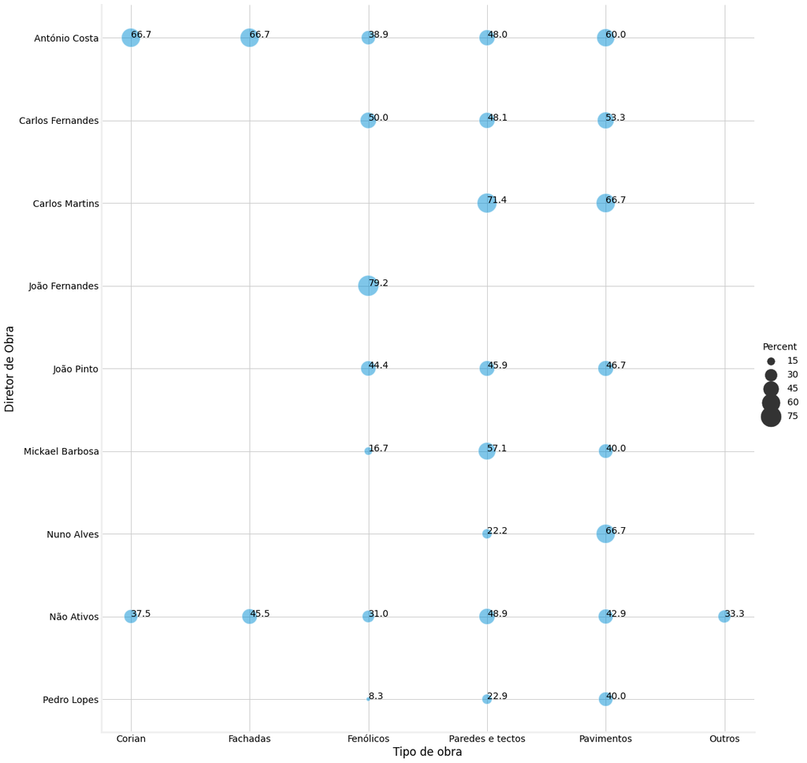

```python
#plt.figure(figsize=(30, 16))
g = sns.relplot(x="Tipoobra",
            y="Directorobra",
           # hue="Tipoobra",
            size="Percent",
            sizes=(40, 1000),
            alpha=.5,
            palette="muted",
            height=16,
            data=Desvios_diretor_df)
g.set(xlabel='Tipo de obra',ylabel='Diretor de Obra')
for line in range(0,Desvios_diretor_df.shape[0]):
    plt.text(Desvios_diretor_df.Tipoobra[line],
              Desvios_diretor_df.Directorobra[line],
              Desvios_diretor_df.Percent[line],
              horizontalalignment='left',
              size='medium',
              color='black',
              weight='regular',
            )
```

```
[Text(0.5, 59.139999999999944, 'Tipo de obra'), Text(151.3, 0.5, 'Área')]
```

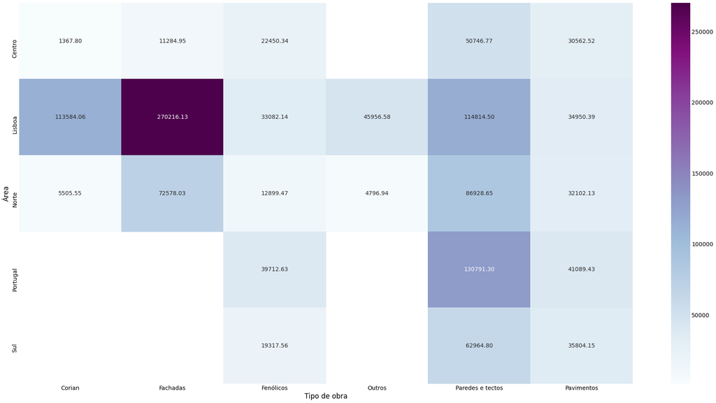

```python
plt.figure(figsize=(30, 16))
df_pt= df1.loc[(df1['Area']!= "França") &
            (df1['Area']!= "Moçambique") &
            (df1['Area']!= "Reino Unido") &
            (df1['Area']!= "Chile") &
            (df1['Area']!= "Camarões") &
            (df1['Area']!= "Guiné Equatorial") &
            (df1['Area']!= "Argélia") &
            (df1['Area']!= "Ghana")  ]


mapacalor = df_pt.pivot_table(values='Custos previstos obra', index="Area",columns="Tipoobra")
g= sns.heatmap(mapacalor, annot=True,fmt='.2f',cmap="BuPu")
g.set(xlabel='Tipo de obra',ylabel='Área')
```

```
[Text(0.5, 59.139999999999944, 'Tipo de obra'), Text(151.3, 0.5, 'Área')]
```

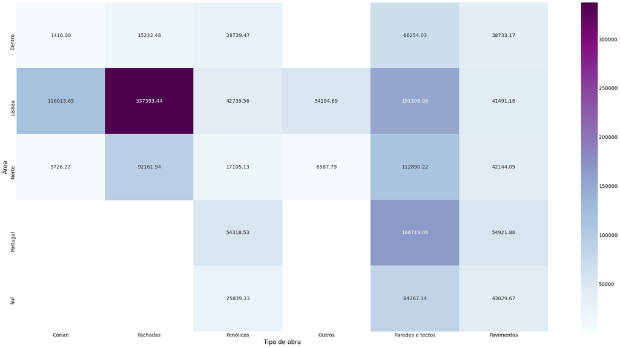

```python
mapacalor_fatura = df_pt.pivot_table(values='Facturação prevista obra', index="Area",columns="Tipoobra")
plt.figure(figsize=(30, 16))
g=sns.heatmap(mapacalor_fatura, annot=True,fmt='.2f',cmap="BuPu")
g.set(xlabel='Tipo de obra',ylabel='Área')
```

```
[Text(0.5, 0, 'Custos previstos obra(€)'),
```

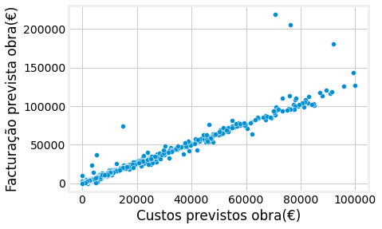

```python
df_custos = df1.loc[(df1["Custos previstos obra"]<100000)]
#df_custos = df_custos.loc[(df_custos["Facturação prevista obra"]>-5000)&(df1["Facturação prevista obra"]<5000)]

#plt.figure(figsize=(30, 16))

g = sns.scatterplot(
    data=df_custos,
    x="Custos previstos obra",
    y="Facturação prevista obra",
    #hue="Desvios_custo_total_categorico",
    palette = "Set2"
)
g.set(xlabel='Custos previstos obra(€)',ylabel='Facturação prevista obra(€)')
```

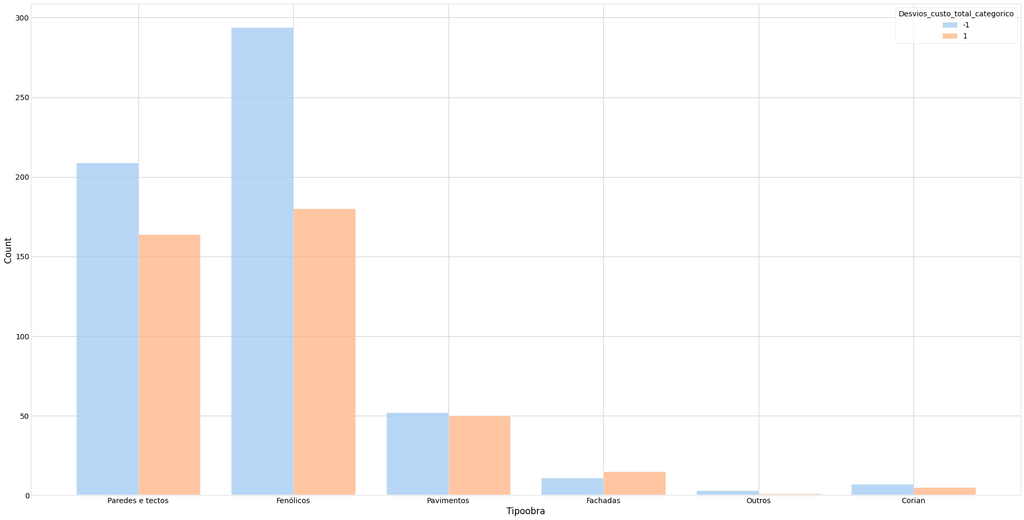

```python
plt.figure(figsize=(30, 16))

g = sns.histplot(
    data=df1,
    x="Tipoobra",
    hue="Desvios_custo_total_categorico",
    multiple="dodge",
    discrete=True,
    shrink=.8,
    palette = "pastel"
)
```

### Classification

After understanding the date, we felt ready to aplly machine learning to it, in order to predict if the costs of a future construcion work would be positive or negative.

Firstly, a cluster was done in order to discover the natural grouping in the data. We found out the appropriate number of clusters to we had to divide our data into. Then we proceeded to visualize the clusters.

```python
from sklearn.cluster import KMeans
import numpy as np

kmeans_kwargs = {
    "init": "random",
    "n_init": 10,
    "max_iter": 300,
    "random_state": 42,
}

# A list holds the SSE values for each k
sse = []
for k in range(1, 11):
    kmeans = KMeans(n_clusters=k, **kmeans_kwargs)
    kmeans.fit(df1)
    sse.append(kmeans.inertia_)
```

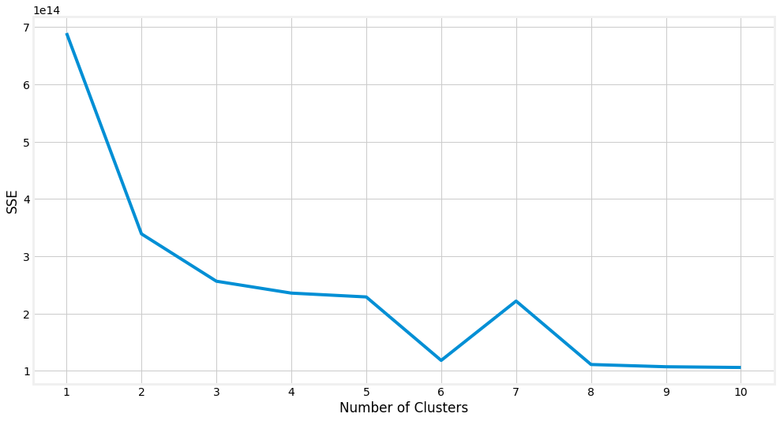

```python
plt.style.use("fivethirtyeight")
plt.rcParams['figure.facecolor'] = 'white'
plt.rcParams['axes.facecolor'] = 'white'

plt.figure(figsize=(15, 8))
plt.plot(range(1, 11), sse)
plt.xticks(range(1, 11))
plt.xlabel("Number of Clusters")
plt.ylabel("SSE")
plt.show()
```

Using knee locator we can find out what number of clusters we shoud use.

```python
from kneed import KneeLocator

kl = KneeLocator(
    range(1, 11), sse, curve="convex", direction="decreasing"
)

kl.elbow
```

```
3
```

#### Visualizing the cluster

```
[Text(0.5, 0, 'custos_previstos_obra(€)'),
```

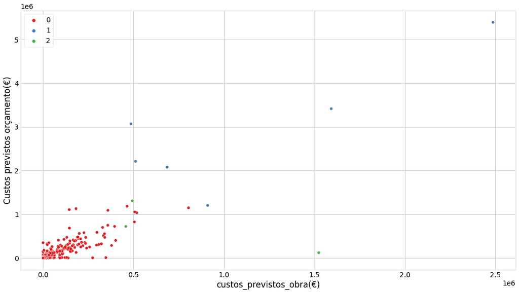

```python
kmeans = KMeans(n_clusters=3, random_state=0).fit(df1)
labels = kmeans.labels_


plt.figure(figsize =(16,9))
g=sns.scatterplot(x="custos_prevserv_obra",
                 y="custos_previstos_orc",
                 data=df1,
                 hue=kmeans.labels_,
               palette="Set1");
g.set(xlabel='custos_previstos_obra(€)',ylabel='Custos previstos orçamento(€)')
```

From visualizing the different clusters we can see that clusters 1 and 2 are of very small sizes. From this we decided to treat them like outliers and cut them out of the data.

```python
from sklearn.model_selection import train_test_split

X = df1.drop(['Desvios_custo_total_categorico',"cluster","processo_cat"] , axis=1)
y = df1["Desvios_custo_total_categorico"]

X_train, X_test, y_train, y_test = train_test_split(X, y, test_size=0.33, random_state=42)
```

```python
from sklearn.metrics import roc_curve
from sklearn.metrics import roc_auc_score

#p_proba_b = b.predict_proba(X_test)
#p_proba_svc = svc.predict_proba(X_test)
p_proba_knc = knc.predict_proba(X_test)
p_proba_lda = lda.predict_proba(X_test)
p_proba_svc = svc.predict_proba(X_test)
p_proba_rf = rf.predict_proba(X_test)
p_proba_vc = vc.predict_proba(X_test)

#roc_score_b = roc_auc_score(y_test, p_proba_b[:,1])
#roc_score_svc = roc_auc_score(y_test, p_proba_svc[:,1])
roc_score_knc = roc_auc_score(y_test, p_proba_knc[:,1])
roc_score_lda = roc_auc_score(y_test, p_proba_lda[:,1])
roc_score_svc = roc_auc_score(y_test, p_proba_svc[:,1])
roc_score_rf = roc_auc_score(y_test, p_proba_rf[:,1])
roc_score_vc = roc_auc_score(y_test, p_proba_vc[:,1])

#False_pos_rate_b, True_pos_rate_b, _ = roc_curve(y_test, p_proba_b[:,1])
#False_pos_rate_svc, True_pos_rate_svc, _ = roc_curve(y_test, p_proba_svc[:,1])
False_pos_rate_knc, True_pos_rate_knc, _ = roc_curve(y_test, p_proba_knc[:,1])
False_pos_rate_lda, True_pos_rate_lda, _ = roc_curve(y_test, p_proba_lda[:,1])
False_pos_rate_svc, True_pos_rate_svc, _ = roc_curve(y_test, p_proba_svc[:,1])
False_pos_rate_rf, True_pos_rate_rf, _ = roc_curve(y_test, p_proba_rf[:,1])
False_pos_rate_vc, True_pos_rate_vc, _ = roc_curve(y_test, p_proba_vc[:,1])

ns_probs = [0 for _ in range(len(y_test))]
ns_fpr, ns_tpr, _ = roc_curve(y_test, ns_probs)
```

```
KNeighbors Classifier: ROC AUC=0.621
Linear Discriminant Analysis: ROC AUC=0.639
SVC: ROC AUC=0.663
Random Forest: ROC AUC=0.687
Voting Classifier: ROC AUC=0.698
```

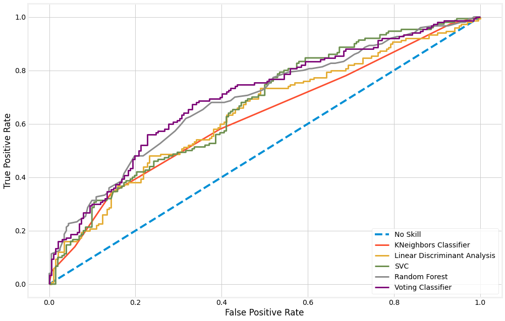

```python
#print('Logistic_0: ROC AUC=%.3f' % (roc_score_0))
#print('Logistic_1: ROC AUC=%.3f' % (roc_score_1))
#print('BernoulliNB: ROC AUC=%.3f' % (roc_score_b))
#print('Support Vector Classification: ROC AUC=%.3f' % (roc_score_svc))
print('KNeighbors Classifier: ROC AUC=%.3f' % (roc_score_knc))
print('Linear Discriminant Analysis: ROC AUC=%.3f' % (roc_score_lda))
print('SVC: ROC AUC=%.3f' % (roc_score_svc))
print('Random Forest: ROC AUC=%.3f' % (roc_score_rf))
print('Voting Classifier: ROC AUC=%.3f' % (roc_score_vc))


plt.figure(figsize=(15, 10))
plt.plot(ns_fpr, ns_tpr, linestyle='--', label='No Skill')
#plt.plot(False_pos_rate_b, True_pos_rate_b, marker=',', label='BernoulliNB',linewidth=3)
#plt.plot(False_pos_rate_svc, True_pos_rate_svc, marker=',', label='Support Vector Classification',linewidth=3)
plt.plot(False_pos_rate_knc, True_pos_rate_knc, marker=',', label='KNeighbors Classifier',linewidth=3)
plt.plot(False_pos_rate_lda, True_pos_rate_lda, marker=',', label='Linear Discriminant Analysis',linewidth=3)
plt.plot(False_pos_rate_svc, True_pos_rate_svc, marker=',', label='SVC',linewidth=3)
plt.plot(False_pos_rate_rf, True_pos_rate_rf, marker=',', label='Random Forest',linewidth=3)
plt.plot(False_pos_rate_vc, True_pos_rate_vc, marker=',', label='Voting Classifier',linewidth=3)



plt.xlabel('False Positive Rate')
plt.ylabel('True Positive Rate')
# show the legend
plt.legend(loc="lower right")
# show the plot
plt.show()
```

The model that gave the best result was Voting Classifier, with a ROC of 0.698

### Streamlit implementation

If you wanna check the streamlit implementation of the proeject, check out my [github project](https://github.com/LopesJos/ML_project_2/blob/main/main_code.py).